# Data Visualisation - Vinci Reloaded 2026

### Appending Marginal Coordinates via ggExtra

To display individual distributions alongside a joint scatter plot, save the base scatter plot configuration and process it using `ggMarginal()`.

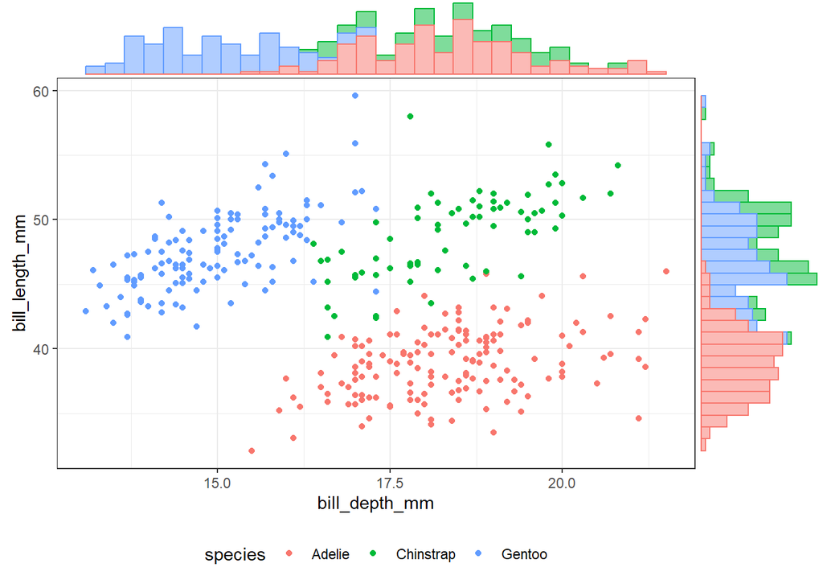

```r
# Save base scatter configuration object
p <- ggplot(penguins, aes(x = bill_depth_mm, y = bill_length_mm, color = species)) +
  geom_point() +
  theme(legend.position = "bottom")

# Generate marginal histogram sub-elements
ggMarginal(p,
           type = "histogram",
           groupColour = TRUE,
           groupFill = TRUE)
```

And with boxplot

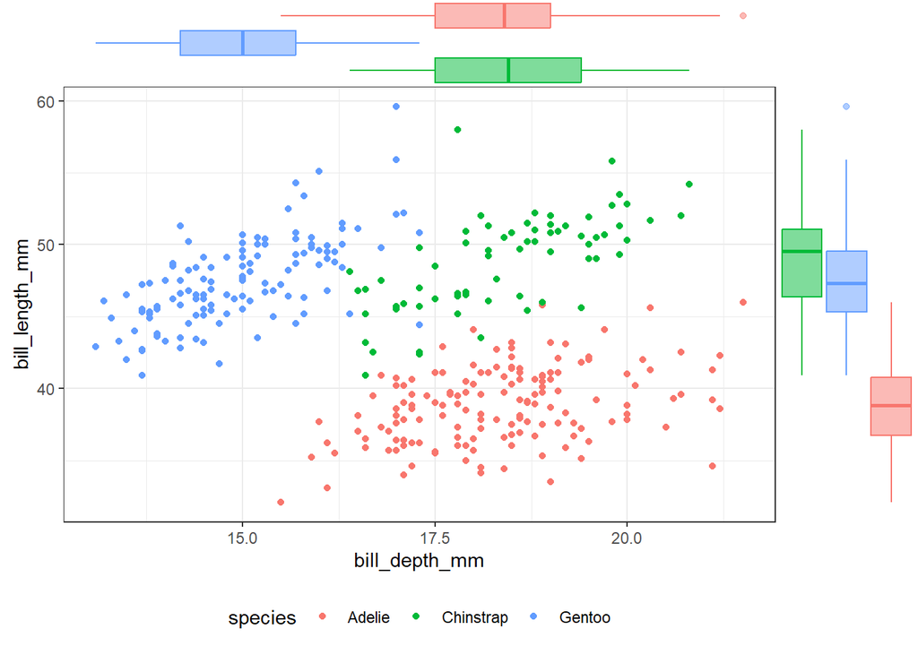

```r
# Generate marginal boxplot sub-elements
ggMarginal(p,
           type = "boxplot",
           groupColour = TRUE,
           groupFill = TRUE)
```

This time density plot:

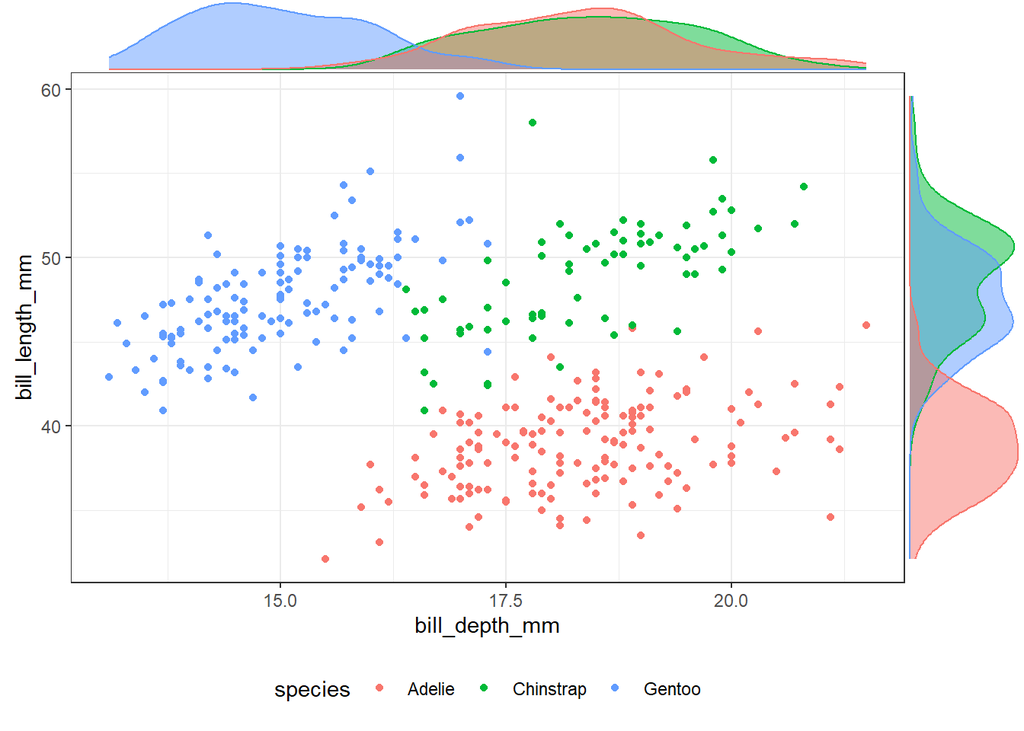

```r
# Plot 3: Scatter with elegant, narrow marginal DENSITY plots
ggMarginal(p,
           type = "density",
           groupColour = TRUE,
           groupFill = TRUE,
           size = 7) # Increases the main plot area, making marginal plots narrower
```

## Things I Found Useful & Interesting

### DataViz Theory & Visual Communication Best Practices

- [Four Steps to Better Data Visualizations](https://www.centerforengagedlearning.org/four-steps-to-better-data-visualizations/) – Practical framework for creating more impactful visualizations.
- [Simplify charts (Medium)](https://medium.com/counterarts/simplicity-is-a-data-visualization-best-friend-4ad4fbec30da) – An insightful read on why simplicity remains the ultimate goal of chart design.
- [Storytelling & Design Chart (Medium)](https://gawarska-tywonek.medium.com/storytelling-a-simple-trick-to-grab-the-user-attention-8b89655e239c) – Straightforward design techniques to capture and retain reader attention.
- [Edward Tufte: Chartjunk](https://www.edwardtufte.com/bboard/q-and-a-fetch-msg?msg_id=00040Z) – A classic introduction to identifying and eliminating visual clutter from charts.
- [Autodesk: Datasaurus Dozen](https://www.autodesk.com/research/publications/same-stats-different-graphs) – A brilliant demonstration of why visualizing data is critical (shows datasets with identical summary statistics but completely different distributions).
- [The Data Visualisation Catalogue](https://datavizcatalogue.com/) – A comprehensive reference library for choosing chart types.

### The Grammar of Graphics & ggplot2 Documentation

- [Hadley Wickham: A Layered Grammar of Graphics (PDF)](http://byrneslab.net/classes/biol607/readings/wickham_layered-grammar.pdf) – The foundational academic paper detailing the structural framework of `ggplot2`.
- [Hadley Wickham: ggplot2. Elegant Graphics for Data Analysis (3rd Ed, online)](https://ggplot2-book.org/) – The complete, free online edition of the official handbook.
- [Claus O. Wilke: Fundamentals of Data Visualization](https://clauswilke.com/dataviz/) – An exceptional online textbook focusing on the principles of accurate data presentation.
- [STHDA: Be Awesome in ggplot2 (Practical Guide)](http://www.sthda.com/english/wiki/be-awesome-in-ggplot2-a-practical-guide-to-be-highly-effective-r-software-and-data-visualization) – Excellent practical reference guide for building highly polished charts.
- [Datanovia: GGplot Examples Best Reference](https://www.datanovia.com/en/blog/ggplot-examples-best-reference/) – Superb reference source covering standard plots and extension packages.
- [Top 50 Ggplot2 Visualizations Master List](http://r-statistics.co/Top50-Ggplot2-Visualizations-MasterList-R-Code.html) – A repository of the 50 most common chart types with reproducible R code.
- [The R Graph Gallery: ggplot2 section](https://r-graph-gallery.com/ggplot2-package.html) – An interactive showcase of inspiration and ready-to-use templates.